# Gráfico de trayectorias - Difusión límite del modelo de Wright-Fisher con selección y mutación

Gerardo Martínez

15 de noviembre de 2018

Para graficar las trayectorias será necesario cargar la función $\texttt{trayectoriasWFMS()}$.

Simularemos $k = 10$ trayectorias en $[0,1]$ de parámetros $\mu_1 = \mu_2 = s_{11} = s_{12} = s_{22} = 0$ y con una precisión de $n = 10^4$; esto es equivalente a simular trayectorias del modelo de Wright-Fisher neutral. Las trayectorias serán simuladas con la función $\texttt{trayectoriasWFMS()}$ y el resultado de estas simulaciones será asignado a una variable llamada *replicas*

```r
replicas <- trayectoriasWFMS(k = 10,
                             n = 1e4,
                             T = 1,
                             p0 = 0.5,
                             N = 100,
                             u1 = 0,
                             u2 = 0,
                             s11 = 0,
                             s12 = 0,
                             s22 = 0)
```

Las trayectorias serán graficadas con el paquete $\texttt{ggplot2}$. Utilizaremos, asimismo, el paquete $\texttt{latex2exp}$ para agregar expresiones matemáticas a los ejes.

```r
library(ggplot2)
library(latex2exp)
```

Para graficar las trayectorias con $\texttt{ggplot2}$ tenemos que construir un dataframe *largo*. Construiremos un data.frame llamado *Trayectorias* que tendrá un vector con los tiempos $t_i$ y los valores de las $k$ trayectorias $X_{t_i}$.

Necesitaremos los valores de $T$, $n$ y $k$ así que los asignaremos como variables generales.

```r
T <- 1
n <- 1e4
k <- 10
```

```r
Trayectorias <- data.frame(seq(from = 0, to = T, by = T/n), replicas)
```

Modificaremos los nombres de las columnas

```r
nombreTrayectoria <- c()
for (i in 1:k){
  nombreTrayectoria <- c(nombreTrayectoria, paste("Trayectoria", i, sep = ""))
}
names(Trayectorias) <- c("Generacion", nombreTrayectoria)
```

La construcción del dataframe *largo* se hará mediante el paquete $\texttt{reshape2}$

```r
library(reshape2)
```

Utilizaremos la función $\texttt{melt}()$ del paquete $\texttt{reshape2}$ para construir el dataframe apropiado para le paquete $\texttt{ggplot2}$.

```r
Trayectorias <- melt(Trayectorias,
                       id.vars = 'Generacion',
                       variable.name = 'Trayectorias')

names(Trayectorias)  <- c("Generacion", "Trayectorias", "Frecuencia")
```

La trayectoria será graficada con la función $\texttt{ggplot()}$. Para cambiar el color de las trayectorias se debe cambiar el parámetro $\texttt{colour=}$ dentro de $\texttt{geom_line()}$.

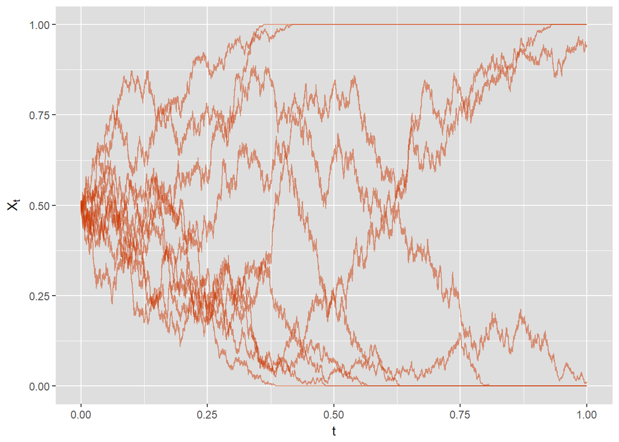

```r
ggplot(Trayectorias,
         aes(Generacion, Frecuencia, group = Trayectorias)) + geom_line(alpha = 0.5, colour="orangered3") + theme(
    panel.background = element_rect(fill = "gray87",
                                  colour = "gray87",
                                  size = 0.5, linetype = "solid"),
    panel.grid.major = element_line(size = 0.5, linetype = 'solid',
                                  colour = "white"),
    panel.grid.minor = element_line(size = 0.25, linetype = 'solid',
                                  colour = "white")
    ) + coord_cartesian(ylim = c(0, 1), xlim = c(0, T)) +
  ylab(TeX("X_t")) +
  xlab(TeX("t"))
```